Universitas Padjadjaran · FMIPA · Departemen Statistika [Portal S2 Statistika Terapan ↗](https://statistika-unpad.github.io/pasca-statistika-web/)

Coaching Riset · Sesi 2

# Menajamkan Metodologi dan Arah Riset Mahasiswa

Forum pendampingan riset intensif untuk memperkuat keterkaitan antara pertanyaan penelitian, struktur data, pemilihan model statistik, validasi, serta interpretasi hasil yang bertanggung jawab.

📅 Sabtu, 22 Agustus 2026 🕗 08.00 WIB – selesai 📍 Ruang Diskusi Lt. 3, Departemen Statistika FMIPA Unpad 👥 5 mahasiswa

Coaching Riset Sesi 2 · 22.08.2026

Berita Akademik

Program Studi Magister (S2) Statistika Terapan FMIPA Universitas Padjadjaran kembali menyelenggarakan **Coaching Riset Sesi 2** pada Sabtu, 22 Agustus 2026. Kegiatan dimulai pukul 08.00 WIB di Ruang Diskusi Lantai 3, Gedung Departemen Statistika FMIPA Unpad, dan berlangsung dalam format klinik riset yang menempatkan setiap mahasiswa sebagai pusat pembahasan.

Sesi kedua diikuti oleh lima mahasiswa dengan spektrum kajian yang luas: kesehatan, sosial, kebijakan publik, sains data, statistika Bayesian, inferensi kausal, serta pemodelan spasio-temporal. Keragaman topik ini menunjukkan bagaimana statistika terapan berperan sebagai jembatan antara persoalan substantif dan pengambilan keputusan berbasis data.

**Fokus utama coaching:** bukan sekadar memilih metode yang paling canggih, melainkan memastikan bahwa *research question*, desain data, estimand, asumsi model, strategi validasi, dan interpretasi hasil berada dalam satu alur ilmiah yang konsisten.

## Lima Topik Riset yang Dibahas

01 · Bayesian Multilevel

### Ega Saherti

Analisis Faktor-Faktor yang Berkaitan dengan Kejadian Bullying pada Mahasiswa Menggunakan Model Logistik Bivariat Multilevel Bayesian

Pembahasan diarahkan pada struktur respons biner yang saling berkaitan, hierarki data, spesifikasi prior, serta interpretasi ketidakpastian posterior.

02 · Explainable AI

### Mahdayani Putri Yunizar

Explainable Stacking Ensemble untuk Pemodelan Jumlah Kasus dan Faktor Risiko Tuberkulosis Berbasis Big Data Kesehatan Indonesia

Fokus metodologis meliputi pemodelan data cacah, arsitektur base learner–meta learner, validasi prediktif, dan interpretabilitas faktor risiko.

03 · Causal Inference

### Linda Apriliana

Analisis Heterogenitas Program Keluarga Harapan (PKH) di Provinsi Nusa Tenggara Barat Menggunakan Metode Causal Forest

Diskusi menekankan definisi treatment dan outcome, confounding, overlap, serta perbedaan antara asosiasi prediktif dan heterogeneous treatment effect.

04 · Spatial Statistics

### Kiki Amelia

Pemodelan Bayesian Spasio-Temporal dan Klasterisasi Wilayah Berdasarkan Risiko Stunting pada Balita di Jawa Barat

Poin penting mencakup dependensi spasial-temporal, risiko relatif, ketidakpastian posterior, dan kestabilan pembentukan klaster wilayah.

05 · Bayesian Multinomial

### Andrew Hosea Talakua

Analisis Faktor-Faktor yang Memengaruhi Penggunaan Metode Kontrasepsi pada Pasangan Usia Subur di Kota Ambon Tahun 2024 Menggunakan Bayesian Regresi Logistik Multinomial

Pembahasan meliputi penentuan kategori referensi, formulasi probabilitas kategori, spesifikasi prior, interpretasi parameter, dan pemeriksaan kecocokan model.

## Dari Aplikasi ke Ketepatan Metodologi

Pembahasan berlangsung pada dua lapisan yang saling melengkapi. Pada sisi aplikasi, setiap penelitian ditinjau dari relevansi masalah, definisi populasi, variabel respons, kovariat, dan makna substantif dari parameter yang akan diestimasi. Pada sisi metodologi, diskusi diarahkan pada struktur probabilistik model, asumsi, strategi estimasi, pengukuran ketidakpastian, diagnostik, validasi, serta batas interpretasi yang dapat dipertanggungjawabkan.

- 1

  **Rumusan masalah & estimand.** Memastikan pertanyaan penelitian dapat diterjemahkan menjadi target estimasi atau target prediksi yang jelas.
- 2

  **Struktur data.** Mengidentifikasi data hierarkis, spasial, temporal, multikategori, data cacah, serta potensi ketergantungan antarpengamatan.
- 3

  **Pemilihan model.** Menilai kesesuaian metode dengan mekanisme data, bukan semata mengikuti tren metodologi.
- 4

  **Validasi dan diagnostik.** Memeriksa performa prediktif, kecocokan model, sensitivitas, dan konsistensi inferensi.
- 5

  **Interpretasi & komunikasi.** Menjaga agar kesimpulan statistik tetap sejalan dengan desain penelitian dan konteks substantif.

## Budaya Riset yang Kolaboratif

Coaching riset dirancang sebagai ruang diskusi terbuka yang mendorong mahasiswa untuk menguji argumentasi ilmiah, menerima kritik metodologis, dan menyempurnakan rancangan analisis secara iteratif. Proses ini penting agar penggunaan metode statistik lanjutan tetap transparan, reproducible, dan relevan terhadap persoalan nyata yang sedang diteliti.

Setelah rangkaian diskusi akademik, kegiatan dilanjutkan dengan makan siang bersama di **Bootcamp Fapet Unpad, Jatinangor**. Suasana informal di akhir sesi menjadi bagian dari penguatan interaksi, kebersamaan, dan komunikasi akademik antarpeserta.

Ringkasan Kegiatan

### Coaching Riset Sesi 2

Tanggal**Sabtu, 22 Agustus 2026**

Waktu**08.00 WIB – selesai**

Lokasi utama**Ruang Diskusi Lt. 3, Gedung Departemen Statistika FMIPA Unpad**

Peserta**5 mahasiswa**

Penutup**Makan siang bersama di Bootcamp Fapet Unpad, Jatinangor**

**Spektrum metodologi**

Bayesian multilevel · stacking ensemble · explainable AI · causal forest · Bayesian spatio-temporal · clustering · multinomial logistic.

**Arah pembinaan**

Ketajaman pertanyaan riset, ketepatan metode, validasi, interpretasi, dan kesiapan menuju karya ilmiah yang solid.

Dokumentasi

## Rangkaian Coaching Riset Sesi 2

Galeri dipilih dari sudut yang berbeda agar tidak menampilkan foto yang berulang atau nyaris identik.

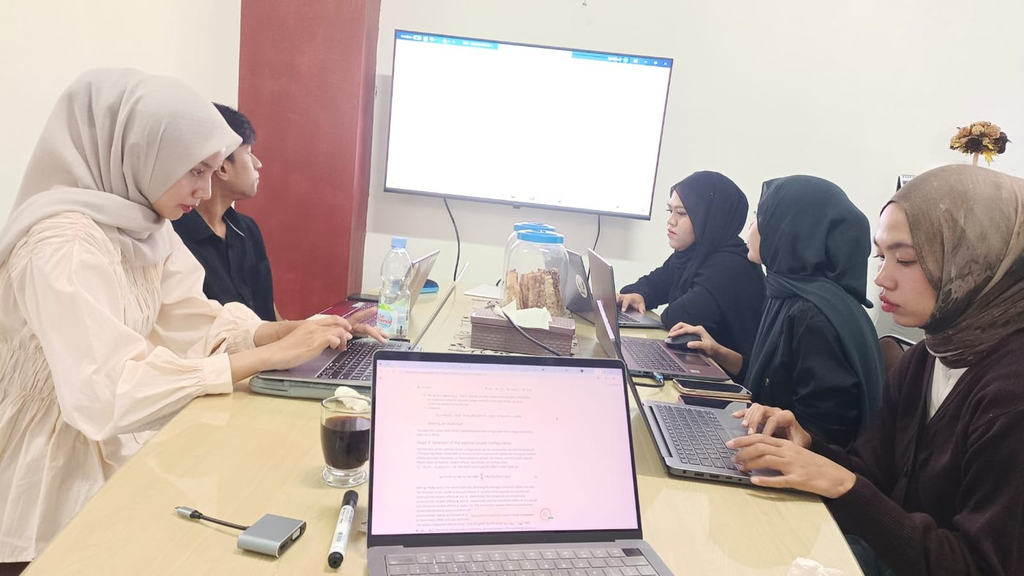

Diskusi metodologi dan telaah perkembangan riset mahasiswa.

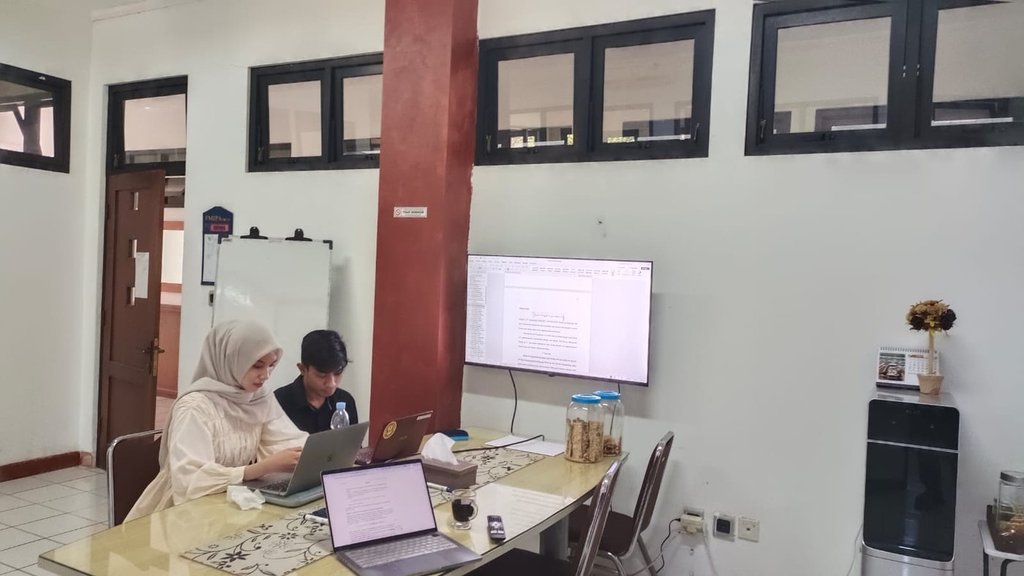

Suasana kerja di Ruang Diskusi Lantai 3.

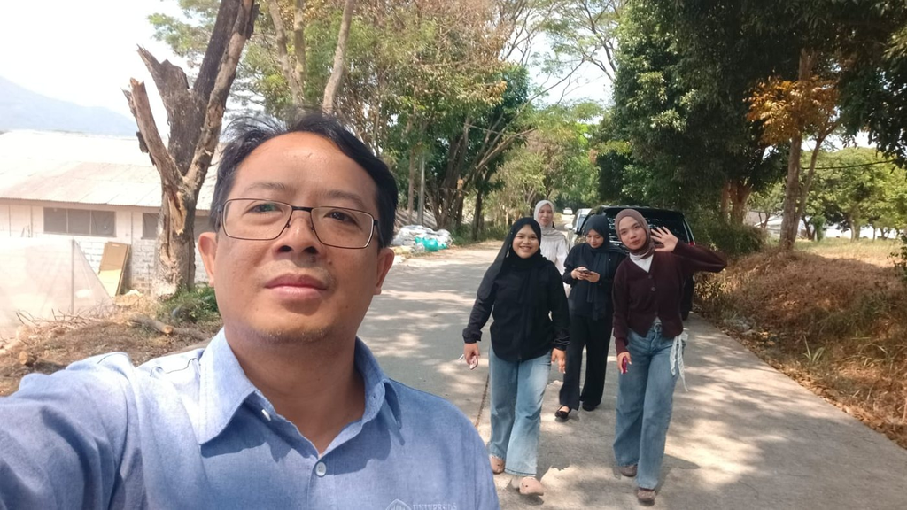

Transisi dari sesi akademik menuju agenda kebersamaan.

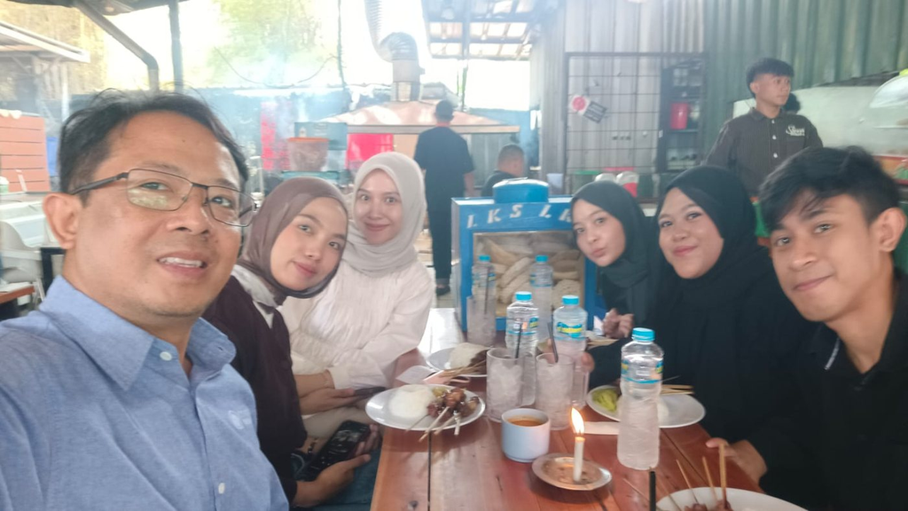

Makan siang bersama sebagai penutup kegiatan.

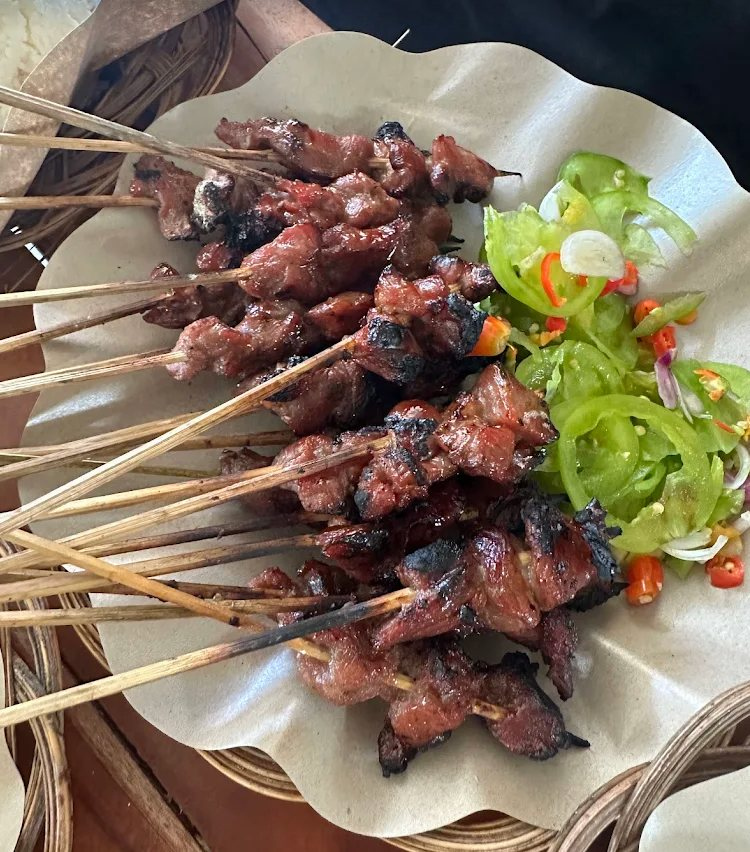

Penutup sesi di Bootcamp Fapet Unpad, Jatinangor.

## Dari pertanyaan yang baik menuju model yang tepat.

Coaching Riset menjadi bagian dari ekosistem akademik S2 Statistika Terapan FMIPA Unpad untuk membangun penelitian yang kuat secara metodologis, relevan secara substantif, dan mampu dikomunikasikan dengan jelas kepada komunitas ilmiah maupun pemangku kepentingan.

[figure not shown]